# Risk Factor Analysis

## Outcome Variable

**Outcome Variable:** ever_sstunted

## Predictor Variables

**Intervention Variable:** mbmi

**Adjustment Set:**

unadjusted

## Stratifying Variables

The analysis was stratified on these variable(s):

- agecat
- studyid
- country

## Data Summary

| agecat | studyid | country | mbmi | ever_sstunted | n_cell | n | outcome_variable |
| --- | --- | --- | --- | --- | --- | --- | --- |
| 0-24 months | ki0047075b-MAL-ED | BANGLADESH | Normal weight | 0 | 176 | 254 | ever_sstunted |
| 0-24 months | ki0047075b-MAL-ED | BANGLADESH | Normal weight | 1 | 46 | 254 | ever_sstunted |
| 0-24 months | ki0047075b-MAL-ED | BANGLADESH | Underweight | 0 | 22 | 254 | ever_sstunted |
| 0-24 months | ki0047075b-MAL-ED | BANGLADESH | Underweight | 1 | 10 | 254 | ever_sstunted |
| 0-24 months | ki0047075b-MAL-ED | BRAZIL | Normal weight | 0 | 192 | 221 | ever_sstunted |
| 0-24 months | ki0047075b-MAL-ED | BRAZIL | Normal weight | 1 | 19 | 221 | ever_sstunted |
| 0-24 months | ki0047075b-MAL-ED | BRAZIL | Underweight | 0 | 8 | 221 | ever_sstunted |
| 0-24 months | ki0047075b-MAL-ED | BRAZIL | Underweight | 1 | 2 | 221 | ever_sstunted |
| 0-24 months | ki0047075b-MAL-ED | INDIA | Normal weight | 0 | 148 | 242 | ever_sstunted |
| 0-24 months | ki0047075b-MAL-ED | INDIA | Normal weight | 1 | 45 | 242 | ever_sstunted |
| 0-24 months | ki0047075b-MAL-ED | INDIA | Underweight | 0 | 36 | 242 | ever_sstunted |
| 0-24 months | ki0047075b-MAL-ED | INDIA | Underweight | 1 | 13 | 242 | ever_sstunted |
| 0-24 months | ki0047075b-MAL-ED | NEPAL | Normal weight | 0 | 217 | 238 | ever_sstunted |
| 0-24 months | ki0047075b-MAL-ED | NEPAL | Normal weight | 1 | 21 | 238 | ever_sstunted |
| 0-24 months | ki0047075b-MAL-ED | NEPAL | Underweight | 0 | 0 | 238 | ever_sstunted |
| 0-24 months | ki0047075b-MAL-ED | NEPAL | Underweight | 1 | 0 | 238 | ever_sstunted |
| 0-24 months | ki0047075b-MAL-ED | PERU | Normal weight | 0 | 225 | 290 | ever_sstunted |
| 0-24 months | ki0047075b-MAL-ED | PERU | Normal weight | 1 | 60 | 290 | ever_sstunted |
| 0-24 months | ki0047075b-MAL-ED | PERU | Underweight | 0 | 2 | 290 | ever_sstunted |
| 0-24 months | ki0047075b-MAL-ED | PERU | Underweight | 1 | 3 | 290 | ever_sstunted |
| 0-24 months | ki0047075b-MAL-ED | SOUTH AFRICA | Normal weight | 0 | 195 | 270 | ever_sstunted |
| 0-24 months | ki0047075b-MAL-ED | SOUTH AFRICA | Normal weight | 1 | 67 | 270 | ever_sstunted |
| 0-24 months | ki0047075b-MAL-ED | SOUTH AFRICA | Underweight | 0 | 5 | 270 | ever_sstunted |
| 0-24 months | ki0047075b-MAL-ED | SOUTH AFRICA | Underweight | 1 | 3 | 270 | ever_sstunted |
| 0-24 months | ki0047075b-MAL-ED | TANZANIA, UNITED REPUBLIC OF | Normal weight | 0 | 114 | 256 | ever_sstunted |
| 0-24 months | ki0047075b-MAL-ED | TANZANIA, UNITED REPUBLIC OF | Normal weight | 1 | 128 | 256 | ever_sstunted |
| 0-24 months | ki0047075b-MAL-ED | TANZANIA, UNITED REPUBLIC OF | Underweight | 0 | 6 | 256 | ever_sstunted |
| 0-24 months | ki0047075b-MAL-ED | TANZANIA, UNITED REPUBLIC OF | Underweight | 1 | 8 | 256 | ever_sstunted |
| 0-24 months | ki1000304b-SAS-CompFeed | INDIA | Normal weight | 0 | 712 | 1407 | ever_sstunted |
| 0-24 months | ki1000304b-SAS-CompFeed | INDIA | Normal weight | 1 | 316 | 1407 | ever_sstunted |

[output cut: 102 more lines]

The following strata were considered:

- agecat: 0-24 months, studyid: ki0047075b-MAL-ED, country: BANGLADESH
- agecat: 0-24 months, studyid: ki0047075b-MAL-ED, country: BRAZIL
- agecat: 0-24 months, studyid: ki0047075b-MAL-ED, country: INDIA
- agecat: 0-24 months, studyid: ki0047075b-MAL-ED, country: NEPAL
- agecat: 0-24 months, studyid: ki0047075b-MAL-ED, country: PERU
- agecat: 0-24 months, studyid: ki0047075b-MAL-ED, country: SOUTH AFRICA
- agecat: 0-24 months, studyid: ki0047075b-MAL-ED, country: TANZANIA, UNITED REPUBLIC OF
- agecat: 0-24 months, studyid: ki1000304b-SAS-CompFeed, country: INDIA
- agecat: 0-24 months, studyid: ki1017093-NIH-Birth, country: BANGLADESH
- agecat: 0-24 months, studyid: ki1017093b-PROVIDE, country: BANGLADESH
- agecat: 0-24 months, studyid: ki1017093c-NIH-Crypto, country: BANGLADESH
- agecat: 0-24 months, studyid: ki1066203-TanzaniaChild2, country: TANZANIA, UNITED REPUBLIC OF
- agecat: 0-24 months, studyid: ki1112895-iLiNS-Zinc, country: BURKINA FASO
- agecat: 0-24 months, studyid: ki1119695-PROBIT, country: BELARUS
- agecat: 0-24 months, studyid: ki1126311-ZVITAMBO, country: ZIMBABWE
- agecat: 0-24 months, studyid: ki1148112-LCNI-5, country: MALAWI
- agecat: 0-24 months, studyid: kiGH5241-JiVitA-3, country: BANGLADESH
- agecat: 0-6 months, studyid: ki0047075b-MAL-ED, country: BANGLADESH
- agecat: 0-6 months, studyid: ki0047075b-MAL-ED, country: BRAZIL
- agecat: 0-6 months, studyid: ki0047075b-MAL-ED, country: INDIA
- agecat: 0-6 months, studyid: ki0047075b-MAL-ED, country: NEPAL
- agecat: 0-6 months, studyid: ki0047075b-MAL-ED, country: PERU
- agecat: 0-6 months, studyid: ki0047075b-MAL-ED, country: SOUTH AFRICA
- agecat: 0-6 months, studyid: ki0047075b-MAL-ED, country: TANZANIA, UNITED REPUBLIC OF
- agecat: 0-6 months, studyid: ki1000304b-SAS-CompFeed, country: INDIA
- agecat: 0-6 months, studyid: ki1017093-NIH-Birth, country: BANGLADESH
- agecat: 0-6 months, studyid: ki1017093b-PROVIDE, country: BANGLADESH
- agecat: 0-6 months, studyid: ki1017093c-NIH-Crypto, country: BANGLADESH
- agecat: 0-6 months, studyid: ki1066203-TanzaniaChild2, country: TANZANIA, UNITED REPUBLIC OF
- agecat: 0-6 months, studyid: ki1119695-PROBIT, country: BELARUS
- agecat: 0-6 months, studyid: ki1126311-ZVITAMBO, country: ZIMBABWE
- agecat: 0-6 months, studyid: ki1148112-LCNI-5, country: MALAWI
- agecat: 0-6 months, studyid: kiGH5241-JiVitA-3, country: BANGLADESH

### Dropped Strata

Some strata were dropped due to rare outcomes:

- agecat: 0-24 months, studyid: ki0047075b-MAL-ED, country: BRAZIL
- agecat: 0-24 months, studyid: ki0047075b-MAL-ED, country: NEPAL
- agecat: 0-24 months, studyid: ki0047075b-MAL-ED, country: PERU
- agecat: 0-24 months, studyid: ki0047075b-MAL-ED, country: SOUTH AFRICA
- agecat: 0-24 months, studyid: ki1066203-TanzaniaChild2, country: TANZANIA, UNITED REPUBLIC OF
- agecat: 0-6 months, studyid: ki0047075b-MAL-ED, country: BANGLADESH
- agecat: 0-6 months, studyid: ki0047075b-MAL-ED, country: BRAZIL
- agecat: 0-6 months, studyid: ki0047075b-MAL-ED, country: NEPAL
- agecat: 0-6 months, studyid: ki0047075b-MAL-ED, country: PERU
- agecat: 0-6 months, studyid: ki0047075b-MAL-ED, country: SOUTH AFRICA
- agecat: 0-6 months, studyid: ki0047075b-MAL-ED, country: TANZANIA, UNITED REPUBLIC OF
- agecat: 0-6 months, studyid: ki1017093b-PROVIDE, country: BANGLADESH
- agecat: 0-6 months, studyid: ki1066203-TanzaniaChild2, country: TANZANIA, UNITED REPUBLIC OF
- agecat: 0-6 months, studyid: ki1148112-LCNI-5, country: MALAWI

## Methods Detail

We’re interested in the causal parameters $E[Y_a]$ for all values of $a \in \mathcal{A}$. These parameters represent the mean outcome if, possibly contrary to fact, we intervened to set all units to have $A=a$. Under the randomization and positivity assumptions, these are identified by the statistical parameters $\psi_a=E_W[E_{Y|A,W}(Y|A=a,W)]$. In addition, we’re interested in the mean of $Y$, $E[Y]$ under no intervention (the observed mean). We will estimate these parameters by using SuperLearner to fit the relevant likelihood factors – $E_{Y|A,W}(Y|A=a,W)$ and $p(A=a|W)$, and then updating our likelihood fit using a joint TMLE.

For unadjusted analyses ($W=\{\}$), initial likelihoods were estimated using Lrnr_glm to estimate the simple $E(Y|A)$ and Lrnr_mean to estimate $p(A)$. For adjusted analyses, a small library containing Lrnr_glmnet, Lrnr_xgboost, and Lrnr_mean was used.

Having estimated these parameters, we will then use the delta method to estimate relative risks and attributable risks relative to a prespecified baseline level of $A$.

# Results Detail

## Results Plots

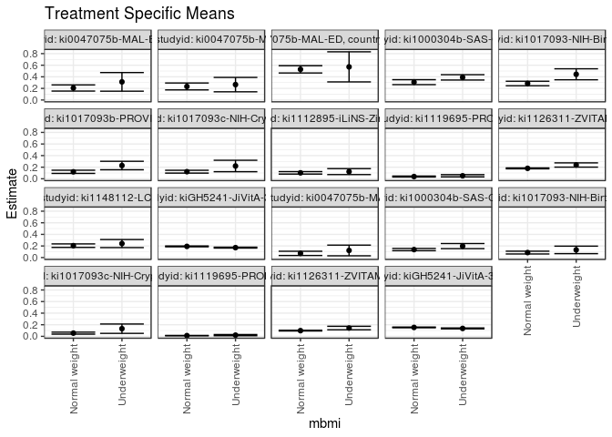

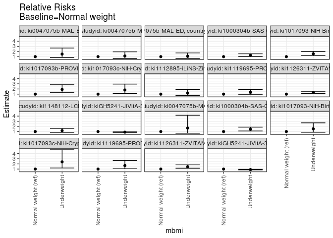

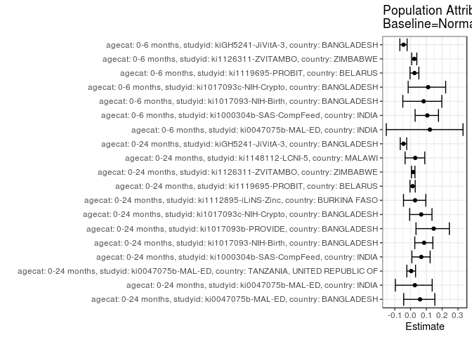

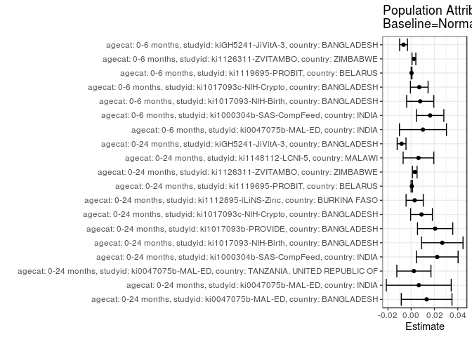

## Results Table

### Parameter: TSM

| agecat | studyid | country | intervention_level | baseline_level | estimate | ci_lower | ci_upper |
| --- | --- | --- | --- | --- | --- | --- | --- |
| 0-24 months | ki0047075b-MAL-ED | BANGLADESH | Normal weight | NA | 0.2072072 | 0.1537864 | 0.2606280 |
| 0-24 months | ki0047075b-MAL-ED | BANGLADESH | Underweight | NA | 0.3125000 | 0.1515870 | 0.4734130 |
| 0-24 months | ki0047075b-MAL-ED | INDIA | Normal weight | NA | 0.2331606 | 0.1733817 | 0.2929396 |
| 0-24 months | ki0047075b-MAL-ED | INDIA | Underweight | NA | 0.2653061 | 0.1414333 | 0.3891790 |
| 0-24 months | ki0047075b-MAL-ED | TANZANIA, UNITED REPUBLIC OF | Normal weight | NA | 0.5289256 | 0.4659123 | 0.5919389 |
| 0-24 months | ki0047075b-MAL-ED | TANZANIA, UNITED REPUBLIC OF | Underweight | NA | 0.5714286 | 0.3116959 | 0.8311612 |
| 0-24 months | ki1000304b-SAS-CompFeed | INDIA | Normal weight | NA | 0.3073930 | 0.2648404 | 0.3499455 |
| 0-24 months | ki1000304b-SAS-CompFeed | INDIA | Underweight | NA | 0.3905013 | 0.3442165 | 0.4367862 |
| 0-24 months | ki1017093-NIH-Birth | BANGLADESH | Normal weight | NA | 0.2848948 | 0.2461807 | 0.3236090 |
| 0-24 months | ki1017093-NIH-Birth | BANGLADESH | Underweight | NA | 0.4433962 | 0.3487486 | 0.5380439 |
| 0-24 months | ki1017093b-PROVIDE | BANGLADESH | Normal weight | NA | 0.1199262 | 0.0925553 | 0.1472971 |
| 0-24 months | ki1017093b-PROVIDE | BANGLADESH | Underweight | NA | 0.2283465 | 0.1552865 | 0.3014064 |
| 0-24 months | ki1017093c-NIH-Crypto | BANGLADESH | Normal weight | NA | 0.1222707 | 0.0977576 | 0.1467839 |
| 0-24 months | ki1017093c-NIH-Crypto | BANGLADESH | Underweight | NA | 0.2205882 | 0.1219703 | 0.3192062 |
| 0-24 months | ki1112895-iLiNS-Zinc | BURKINA FASO | Normal weight | NA | 0.1020999 | 0.0810032 | 0.1231967 |
| 0-24 months | ki1112895-iLiNS-Zinc | BURKINA FASO | Underweight | NA | 0.1233480 | 0.0718839 | 0.1748121 |
| 0-24 months | ki1119695-PROBIT | BELARUS | Normal weight | NA | 0.0383188 | 0.0300884 | 0.0465492 |
| 0-24 months | ki1119695-PROBIT | BELARUS | Underweight | NA | 0.0516252 | 0.0326607 | 0.0705898 |
| 0-24 months | ki1126311-ZVITAMBO | ZIMBABWE | Normal weight | NA | 0.1798538 | 0.1720485 | 0.1876591 |
| 0-24 months | ki1126311-ZVITAMBO | ZIMBABWE | Underweight | NA | 0.2379110 | 0.2012052 | 0.2746169 |
| 0-24 months | ki1148112-LCNI-5 | MALAWI | Normal weight | NA | 0.2052023 | 0.1750949 | 0.2353098 |
| 0-24 months | ki1148112-LCNI-5 | MALAWI | Underweight | NA | 0.2413793 | 0.1716868 | 0.3110718 |
| 0-24 months | kiGH5241-JiVitA-3 | BANGLADESH | Normal weight | NA | 0.1926803 | 0.1857645 | 0.1995961 |
| 0-24 months | kiGH5241-JiVitA-3 | BANGLADESH | Underweight | NA | 0.1711451 | 0.1630863 | 0.1792039 |
| 0-6 months | ki0047075b-MAL-ED | INDIA | Normal weight | NA | 0.0725389 | 0.0358696 | 0.1092081 |
| 0-6 months | ki0047075b-MAL-ED | INDIA | Underweight | NA | 0.1224490 | 0.0304754 | 0.2144225 |
| 0-6 months | ki1000304b-SAS-CompFeed | INDIA | Normal weight | NA | 0.1375610 | 0.1179684 | 0.1571535 |
| 0-6 months | ki1000304b-SAS-CompFeed | INDIA | Underweight | NA | 0.1978892 | 0.1535731 | 0.2422053 |
| 0-6 months | ki1017093-NIH-Birth | BANGLADESH | Normal weight | NA | 0.0860421 | 0.0619895 | 0.1100946 |
| 0-6 months | ki1017093-NIH-Birth | BANGLADESH | Underweight | NA | 0.1320755 | 0.0675706 | 0.1965804 |
| 0-6 months | ki1017093c-NIH-Crypto | BANGLADESH | Normal weight | NA | 0.0553130 | 0.0382083 | 0.0724176 |
| 0-6 months | ki1017093c-NIH-Crypto | BANGLADESH | Underweight | NA | 0.1323529 | 0.0517558 | 0.2129501 |
| 0-6 months | ki1119695-PROBIT | BELARUS | Normal weight | NA | 0.0125710 | 0.0092156 | 0.0159263 |
| 0-6 months | ki1119695-PROBIT | BELARUS | Underweight | NA | 0.0210325 | 0.0109067 | 0.0311583 |
| 0-6 months | ki1126311-ZVITAMBO | ZIMBABWE | Normal weight | NA | 0.0983748 | 0.0923187 | 0.1044309 |
| 0-6 months | ki1126311-ZVITAMBO | ZIMBABWE | Underweight | NA | 0.1431335 | 0.1129442 | 0.1733227 |
| 0-6 months | kiGH5241-JiVitA-3 | BANGLADESH | Normal weight | NA | 0.1538323 | 0.1477185 | 0.1599462 |
| 0-6 months | kiGH5241-JiVitA-3 | BANGLADESH | Underweight | NA | 0.1366886 | 0.1293316 | 0.1440455 |

### Parameter: E(Y)

| agecat | studyid | country | intervention_level | baseline_level | estimate | ci_lower | ci_upper |
| --- | --- | --- | --- | --- | --- | --- | --- |
| 0-24 months | ki0047075b-MAL-ED | BANGLADESH | NA | NA | 0.2204724 | 0.1693889 | 0.2715560 |
| 0-24 months | ki0047075b-MAL-ED | INDIA | NA | NA | 0.2396694 | 0.1857746 | 0.2935643 |
| 0-24 months | ki0047075b-MAL-ED | TANZANIA, UNITED REPUBLIC OF | NA | NA | 0.5312500 | 0.4700011 | 0.5924989 |
| 0-24 months | ki1000304b-SAS-CompFeed | INDIA | NA | NA | 0.3297797 | 0.2987556 | 0.3608038 |
| 0-24 months | ki1017093-NIH-Birth | BANGLADESH | NA | NA | 0.3116057 | 0.2753823 | 0.3478292 |
| 0-24 months | ki1017093b-PROVIDE | BANGLADESH | NA | NA | 0.1405082 | 0.1141551 | 0.1668613 |
| 0-24 months | ki1017093c-NIH-Crypto | BANGLADESH | NA | NA | 0.1311258 | 0.1070332 | 0.1552185 |
| 0-24 months | ki1112895-iLiNS-Zinc | BURKINA FASO | NA | NA | 0.1050995 | 0.0855497 | 0.1246493 |
| 0-24 months | ki1119695-PROBIT | BELARUS | NA | NA | 0.0388258 | 0.0305723 | 0.0470792 |
| 0-24 months | ki1126311-ZVITAMBO | ZIMBABWE | NA | NA | 0.1829107 | 0.1752637 | 0.1905577 |
| 0-24 months | ki1148112-LCNI-5 | MALAWI | NA | NA | 0.2114695 | 0.1837888 | 0.2391503 |
| 0-24 months | kiGH5241-JiVitA-3 | BANGLADESH | NA | NA | 0.1844309 | 0.1788328 | 0.1900291 |
| 0-6 months | ki0047075b-MAL-ED | INDIA | NA | NA | 0.0826446 | 0.0478818 | 0.1174075 |
| 0-6 months | ki1000304b-SAS-CompFeed | INDIA | NA | NA | 0.1538462 | 0.1345929 | 0.1730994 |
| 0-6 months | ki1017093-NIH-Birth | BANGLADESH | NA | NA | 0.0937997 | 0.0709973 | 0.1166021 |
| 0-6 months | ki1017093c-NIH-Crypto | BANGLADESH | NA | NA | 0.0622517 | 0.0450059 | 0.0794974 |
| 0-6 months | ki1119695-PROBIT | BELARUS | NA | NA | 0.0128934 | 0.0095196 | 0.0162671 |
| 0-6 months | ki1126311-ZVITAMBO | ZIMBABWE | NA | NA | 0.1007341 | 0.0947773 | 0.1066909 |
| 0-6 months | kiGH5241-JiVitA-3 | BANGLADESH | NA | NA | 0.1472688 | 0.1422160 | 0.1523215 |

### Parameter: RR

| agecat | studyid | country | intervention_level | baseline_level | estimate | ci_lower | ci_upper |
| --- | --- | --- | --- | --- | --- | --- | --- |
| 0-24 months | ki0047075b-MAL-ED | BANGLADESH | Normal weight | Normal weight | 1.0000000 | 1.0000000 | 1.0000000 |
| 0-24 months | ki0047075b-MAL-ED | BANGLADESH | Underweight | Normal weight | 1.5081522 | 0.8479171 | 2.6824827 |
| 0-24 months | ki0047075b-MAL-ED | INDIA | Normal weight | Normal weight | 1.0000000 | 1.0000000 | 1.0000000 |
| 0-24 months | ki0047075b-MAL-ED | INDIA | Underweight | Normal weight | 1.1378685 | 0.6679713 | 1.9383239 |
| 0-24 months | ki0047075b-MAL-ED | TANZANIA, UNITED REPUBLIC OF | Normal weight | Normal weight | 1.0000000 | 1.0000000 | 1.0000000 |
| 0-24 months | ki0047075b-MAL-ED | TANZANIA, UNITED REPUBLIC OF | Underweight | Normal weight | 1.0803571 | 0.6753029 | 1.7283675 |
| 0-24 months | ki1000304b-SAS-CompFeed | INDIA | Normal weight | Normal weight | 1.0000000 | 1.0000000 | 1.0000000 |
| 0-24 months | ki1000304b-SAS-CompFeed | INDIA | Underweight | Normal weight | 1.2703651 | 1.0361717 | 1.5574902 |
| 0-24 months | ki1017093-NIH-Birth | BANGLADESH | Normal weight | Normal weight | 1.0000000 | 1.0000000 | 1.0000000 |
| 0-24 months | ki1017093-NIH-Birth | BANGLADESH | Underweight | Normal weight | 1.5563505 | 1.2084028 | 2.0044863 |
| 0-24 months | ki1017093b-PROVIDE | BANGLADESH | Normal weight | Normal weight | 1.0000000 | 1.0000000 | 1.0000000 |
| 0-24 months | ki1017093b-PROVIDE | BANGLADESH | Underweight | Normal weight | 1.9040581 | 1.2852775 | 2.8207429 |
| 0-24 months | ki1017093c-NIH-Crypto | BANGLADESH | Normal weight | Normal weight | 1.0000000 | 1.0000000 | 1.0000000 |
| 0-24 months | ki1017093c-NIH-Crypto | BANGLADESH | Underweight | Normal weight | 1.8040966 | 1.1052787 | 2.9447456 |
| 0-24 months | ki1112895-iLiNS-Zinc | BURKINA FASO | Normal weight | Normal weight | 1.0000000 | 1.0000000 | 1.0000000 |
| 0-24 months | ki1112895-iLiNS-Zinc | BURKINA FASO | Underweight | Normal weight | 1.2081107 | 0.7608260 | 1.9183512 |
| 0-24 months | ki1119695-PROBIT | BELARUS | Normal weight | Normal weight | 1.0000000 | 1.0000000 | 1.0000000 |
| 0-24 months | ki1119695-PROBIT | BELARUS | Underweight | Normal weight | 1.3472555 | 0.9660450 | 1.8788953 |
| 0-24 months | ki1126311-ZVITAMBO | ZIMBABWE | Normal weight | Normal weight | 1.0000000 | 1.0000000 | 1.0000000 |
| 0-24 months | ki1126311-ZVITAMBO | ZIMBABWE | Underweight | Normal weight | 1.3228024 | 1.1269121 | 1.5527441 |
| 0-24 months | ki1148112-LCNI-5 | MALAWI | Normal weight | Normal weight | 1.0000000 | 1.0000000 | 1.0000000 |
| 0-24 months | ki1148112-LCNI-5 | MALAWI | Underweight | Normal weight | 1.1762992 | 0.8508719 | 1.6261904 |
| 0-24 months | kiGH5241-JiVitA-3 | BANGLADESH | Normal weight | Normal weight | 1.0000000 | 1.0000000 | 1.0000000 |
| 0-24 months | kiGH5241-JiVitA-3 | BANGLADESH | Underweight | Normal weight | 0.8882337 | 0.8405652 | 0.9386055 |
| 0-6 months | ki0047075b-MAL-ED | INDIA | Normal weight | Normal weight | 1.0000000 | 1.0000000 | 1.0000000 |
| 0-6 months | ki0047075b-MAL-ED | INDIA | Underweight | Normal weight | 1.6880466 | 0.6826237 | 4.1743369 |
| 0-6 months | ki1000304b-SAS-CompFeed | INDIA | Normal weight | Normal weight | 1.0000000 | 1.0000000 | 1.0000000 |
| 0-6 months | ki1000304b-SAS-CompFeed | INDIA | Underweight | Normal weight | 1.4385561 | 1.1136905 | 1.8581857 |
| 0-6 months | ki1017093-NIH-Birth | BANGLADESH | Normal weight | Normal weight | 1.0000000 | 1.0000000 | 1.0000000 |
| 0-6 months | ki1017093-NIH-Birth | BANGLADESH | Underweight | Normal weight | 1.5350105 | 0.8744146 | 2.6946682 |
| 0-6 months | ki1017093c-NIH-Crypto | BANGLADESH | Normal weight | Normal weight | 1.0000000 | 1.0000000 | 1.0000000 |
| 0-6 months | ki1017093c-NIH-Crypto | BANGLADESH | Underweight | Normal weight | 2.3928019 | 1.2086339 | 4.7371672 |
| 0-6 months | ki1119695-PROBIT | BELARUS | Normal weight | Normal weight | 1.0000000 | 1.0000000 | 1.0000000 |
| 0-6 months | ki1119695-PROBIT | BELARUS | Underweight | Normal weight | 1.6730977 | 1.0517535 | 2.6615134 |
| 0-6 months | ki1126311-ZVITAMBO | ZIMBABWE | Normal weight | Normal weight | 1.0000000 | 1.0000000 | 1.0000000 |
| 0-6 months | ki1126311-ZVITAMBO | ZIMBABWE | Underweight | Normal weight | 1.4549814 | 1.1679800 | 1.8125059 |
| 0-6 months | kiGH5241-JiVitA-3 | BANGLADESH | Normal weight | Normal weight | 1.0000000 | 1.0000000 | 1.0000000 |
| 0-6 months | kiGH5241-JiVitA-3 | BANGLADESH | Underweight | Normal weight | 0.8885555 | 0.8354002 | 0.9450930 |

### Parameter: PAR

| agecat | studyid | country | intervention_level | baseline_level | estimate | ci_lower | ci_upper |
| --- | --- | --- | --- | --- | --- | --- | --- |
| 0-24 months | ki0047075b-MAL-ED | BANGLADESH | Normal weight | NA | 0.0132652 | -0.0085248 | 0.0350553 |
| 0-24 months | ki0047075b-MAL-ED | INDIA | Normal weight | NA | 0.0065088 | -0.0213885 | 0.0344061 |
| 0-24 months | ki0047075b-MAL-ED | TANZANIA, UNITED REPUBLIC OF | Normal weight | NA | 0.0023244 | -0.0123398 | 0.0169886 |
| 0-24 months | ki1000304b-SAS-CompFeed | INDIA | Normal weight | NA | 0.0223867 | 0.0044410 | 0.0403324 |
| 0-24 months | ki1017093-NIH-Birth | BANGLADESH | Normal weight | NA | 0.0267109 | 0.0088642 | 0.0445576 |
| 0-24 months | ki1017093b-PROVIDE | BANGLADESH | Normal weight | NA | 0.0205820 | 0.0054244 | 0.0357397 |
| 0-24 months | ki1017093c-NIH-Crypto | BANGLADESH | Normal weight | NA | 0.0088551 | -0.0005152 | 0.0182254 |
| 0-24 months | ki1112895-iLiNS-Zinc | BURKINA FASO | Normal weight | NA | 0.0029996 | -0.0043849 | 0.0103840 |
| 0-24 months | ki1119695-PROBIT | BELARUS | Normal weight | NA | 0.0005069 | -0.0001342 | 0.0011481 |
| 0-24 months | ki1126311-ZVITAMBO | ZIMBABWE | Normal weight | NA | 0.0030569 | 0.0010644 | 0.0050494 |
| 0-24 months | ki1148112-LCNI-5 | MALAWI | Normal weight | NA | 0.0062672 | -0.0069173 | 0.0194517 |
| 0-24 months | kiGH5241-JiVitA-3 | BANGLADESH | Normal weight | NA | -0.0082494 | -0.0120382 | -0.0044606 |
| 0-6 months | ki0047075b-MAL-ED | INDIA | Normal weight | NA | 0.0101058 | -0.0101018 | 0.0303133 |
| 0-6 months | ki1000304b-SAS-CompFeed | INDIA | Normal weight | NA | 0.0162852 | 0.0045184 | 0.0280519 |
| 0-6 months | ki1017093-NIH-Birth | BANGLADESH | Normal weight | NA | 0.0077576 | -0.0039220 | 0.0194372 |
| 0-6 months | ki1017093c-NIH-Crypto | BANGLADESH | Normal weight | NA | 0.0069387 | -0.0006472 | 0.0145246 |
| 0-6 months | ki1119695-PROBIT | BELARUS | Normal weight | NA | 0.0003224 | -0.0000386 | 0.0006833 |
| 0-6 months | ki1126311-ZVITAMBO | ZIMBABWE | Normal weight | NA | 0.0023593 | 0.0007243 | 0.0039944 |
| 0-6 months | kiGH5241-JiVitA-3 | BANGLADESH | Normal weight | NA | -0.0065636 | -0.0099371 | -0.0031901 |

### Parameter: PAF

| agecat | studyid | country | intervention_level | baseline_level | estimate | ci_lower | ci_upper |
| --- | --- | --- | --- | --- | --- | --- | --- |
| 0-24 months | ki0047075b-MAL-ED | BANGLADESH | Normal weight | NA | 0.0601673 | -0.0435371 | 0.1535658 |
| 0-24 months | ki0047075b-MAL-ED | INDIA | Normal weight | NA | 0.0271574 | -0.0964214 | 0.1368075 |
| 0-24 months | ki0047075b-MAL-ED | TANZANIA, UNITED REPUBLIC OF | Normal weight | NA | 0.0043753 | -0.0236201 | 0.0316050 |
| 0-24 months | ki1000304b-SAS-CompFeed | INDIA | Normal weight | NA | 0.0678837 | 0.0083497 | 0.1238436 |
| 0-24 months | ki1017093-NIH-Birth | BANGLADESH | Normal weight | NA | 0.0857201 | 0.0267740 | 0.1410961 |
| 0-24 months | ki1017093b-PROVIDE | BANGLADESH | Normal weight | NA | 0.1464827 | 0.0343833 | 0.2455683 |
| 0-24 months | ki1017093c-NIH-Crypto | BANGLADESH | Normal weight | NA | 0.0675312 | -0.0058990 | 0.1356010 |
| 0-24 months | ki1112895-iLiNS-Zinc | BURKINA FASO | Normal weight | NA | 0.0285403 | -0.0447042 | 0.0966497 |
| 0-24 months | ki1119695-PROBIT | BELARUS | Normal weight | NA | 0.0130568 | -0.0036222 | 0.0294586 |
| 0-24 months | ki1126311-ZVITAMBO | ZIMBABWE | Normal weight | NA | 0.0167125 | 0.0057715 | 0.0275330 |
| 0-24 months | ki1148112-LCNI-5 | MALAWI | Normal weight | NA | 0.0296365 | -0.0346954 | 0.0899687 |
| 0-24 months | kiGH5241-JiVitA-3 | BANGLADESH | Normal weight | NA | -0.0447289 | -0.0654513 | -0.0244094 |
| 0-6 months | ki0047075b-MAL-ED | INDIA | Normal weight | NA | 0.1222798 | -0.1536263 | 0.3321990 |
| 0-6 months | ki1000304b-SAS-CompFeed | INDIA | Normal weight | NA | 0.1058537 | 0.0287862 | 0.1768057 |
| 0-6 months | ki1017093-NIH-Birth | BANGLADESH | Normal weight | NA | 0.0827041 | -0.0491461 | 0.1979842 |
| 0-6 months | ki1017093c-NIH-Crypto | BANGLADESH | Normal weight | NA | 0.1114621 | -0.0151402 | 0.2222753 |
| 0-6 months | ki1119695-PROBIT | BELARUS | Normal weight | NA | 0.0250021 | -0.0034839 | 0.0526794 |
| 0-6 months | ki1126311-ZVITAMBO | ZIMBABWE | Normal weight | NA | 0.0234213 | 0.0071011 | 0.0394732 |
| 0-6 months | kiGH5241-JiVitA-3 | BANGLADESH | Normal weight | NA | -0.0445686 | -0.0677595 | -0.0218815 |